# An Exploration on American Law School Students in 1991

Final Project  
Data Science 1 with R (STAT 301-1)

Author

Sana Nanlawala

Published

December 6, 2023

**Github Link**

[Github Repository](https://github.com/snanlawala15/LSAC_EDA.git)

# Introduction

This report will conduct on exploratory data analysis on a study called the [LSAC National Longitudinal Bar Passage Study](https://eric.ed.gov/?id=ED469370) completed in 1998 by Linda Wightman. This study focuses on 22,407 students who entered law school in fall of 1991.

The motivation for this analysis was to explore not only the demographics of law students entering law school in 1991, but to also understand how these demographics have changed over the past two decades. Law school is a large commitment, financially and otherwise, and understanding how entrance into law school is important context when examining higher education in America and the limitation of these opportunities for certain students because of their background. While personal identification-related variables such as race and gender will be examined, other things that have a direct relation to law school applications like LSAT scores and undergraduate GPAs will also be compared and measured.

# Data Overview

This dataset contains 22,407 observations with 12 variables that are most significant in describing the students entering law school in 1991. Reference the *codebook* for a better understanding of these variables. 6 of these variables are categorical and 6 are numerical variables. These variables have been specifically chosen from the original, raw, data collection after a series of decisions made to best encapsulate the purpose of this data collection and what it was researching.

# Data Exploration

To begin the exploration of this dataset, understanding the demographics of the students in 1991 entering law school was most important to gain any insight or conclusions in the changes in student population today.

An often overlooked demographic variable is age, and in the context of this dataset, the age of students when entering law school (i.e. how old they are in 1991)

### Age:

The original dataset recorded the birth year of each student. To enhance clarity, the collected data was transformed into the age of each student in 1991. Therefore, the reported ages represent the students’ ages as of the year 1991. It’s important to note that these ages may not precisely reflect their ages at the commencement of law school in the fall of 1991, as specific birth dates (days and months) were not provided.

Below is a histogram showing the distribution of law school entrants ages in 1991.

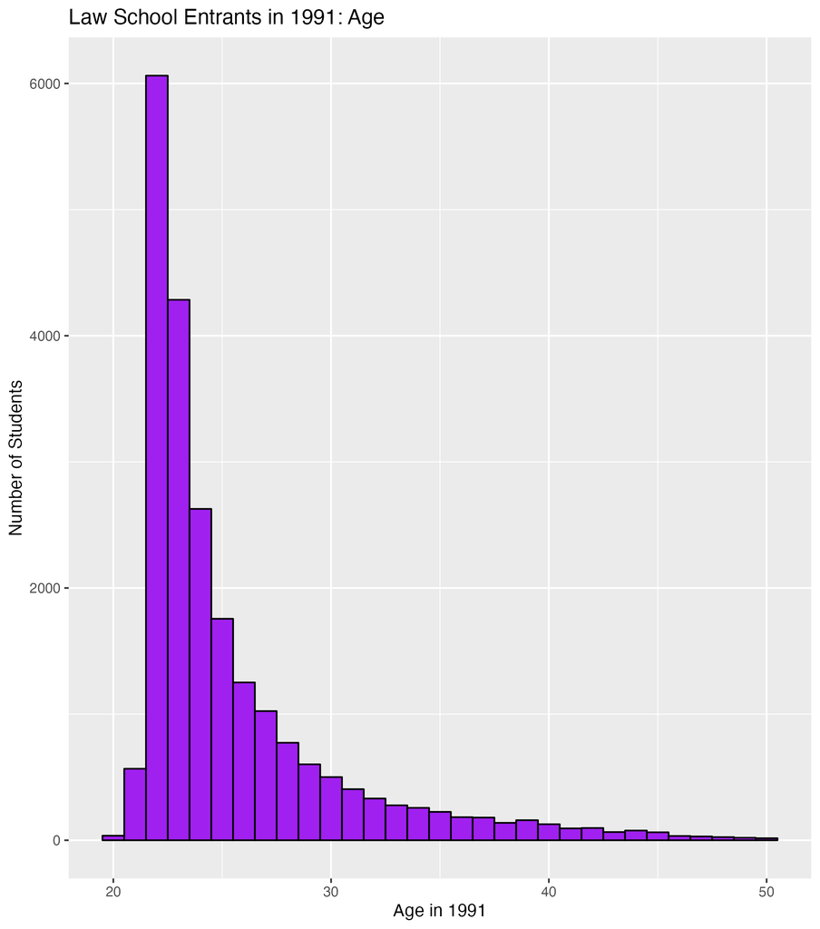

### Race:

This dataset separates race into five categories: Asian, Black, Hispanic, White, and Other. Before examining the distribution of race against any other variable in this dataset, it is important to first get an understanding of this pool of law school entrants in 1991. Below is a distribution of race among 22,391 students. (information on race was missing for 16 students)

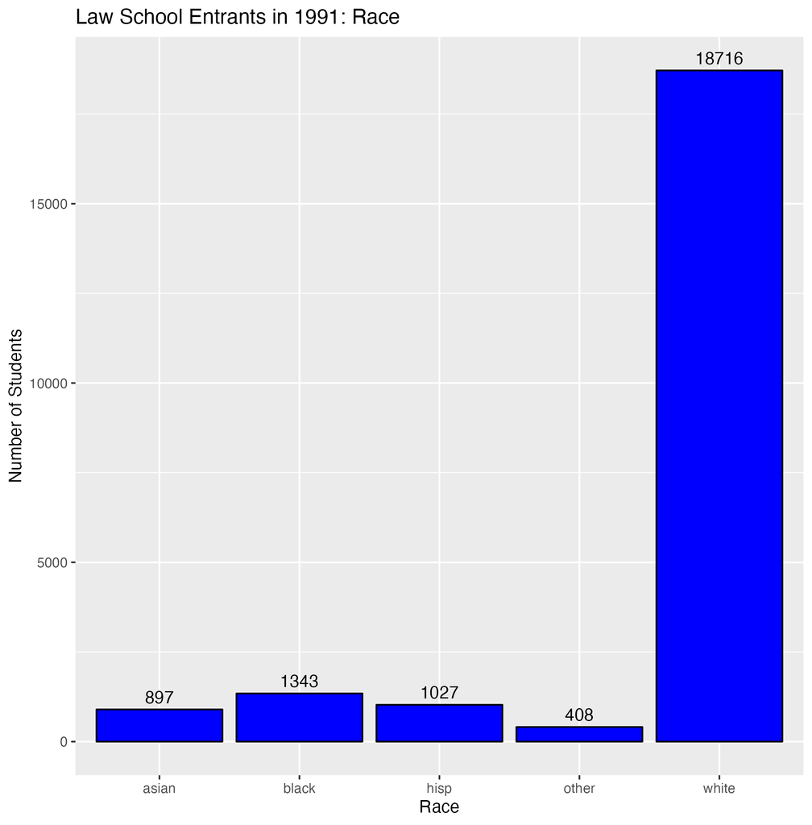

There is a large disparity between the number of white students versus students of any other race for first year law school students in 1991. This, unsurprisingly, has changed in the present day. According to the [Law School Admissions Council (LSAC)](https://www.lsac.org/blog/incoming-class-2022-major-advance-diversity-more-work-to-do), the incoming class of 2022 had 36.6% identify as students of color. More specifically, 7.8% identify as black, 9.4% as Hispanic, and 8.9% identify as Asian. While this information may not be the best form of comparison to this dataset (as the LSAC also considers multi-racial as a separate category and has other forms of identifications). There has been a larger growth in diversity over the past three decades. Below is a more clearer comparison of the two years.

| Race | 1991 | 2022 |
| --- | --- | --- |
| Asian | 4.01% | 8.9% |
| Black | 6% | 7.8% |
| Hispanic | 4.59% | 9.4% |
| White | 83.59% | 57.7% |
| Other | 1.81 | 16.2% |

#### *Race and Family Income:*

This dataset separates the family income variable into five factors, 1-5, with 1 being the lowest family income range and 5 being the highest. While specific ranges of income are not specified, having five ordered factors are helpful in comparing. After examining the large disparities in racial identity of the law school students in 1991, examining the intersectionality between race and income seems like a necessary step in recreating the narrative of law school entrants in 1991.

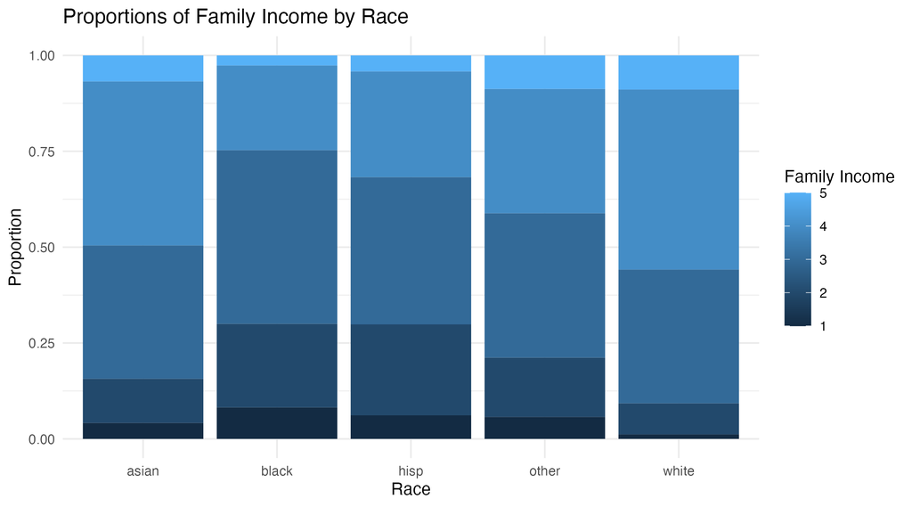

Of all Asian and white law school entrants, most belonged to the 4th family income level. Of the black, hispanic, and other racially-identifying students, the majority belonged to the 3rd family income level.

### Family Income:

As mentioned previously, family income was separated into five categories, numbered 1-5, with 1 being the lowest family income range. Below is a table showing the distribution of family income among the law school entrants in 1991.

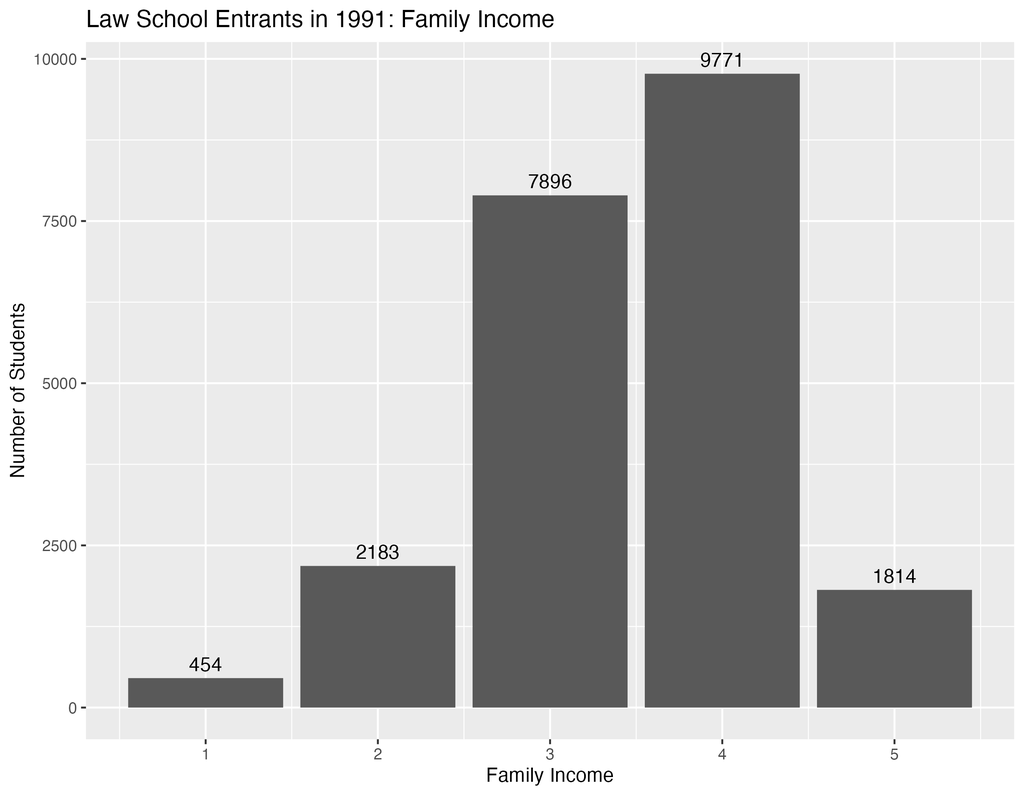

As shown in the plot, most students belonged in the 4th family income range. Law school is a big financial decision as well as any other kind of decision so family income levels may influence this decision. However, it is unknown which applicants had their family supporting them financially for law school, but the sentiment remains that there maybe some influence one’s family income has in making the decision to go to law school.

#### *Fulltime Status and Family Income:*

When exploring the the fulltime or parttime status of students against their family income, which currently is the only variable that gives any financial identification of the student, the expectation was that students were more likely to be parttime if they were of a lower income status, for reasons such as to hold down jobs, etc. However the plot below shows a different conclusion.

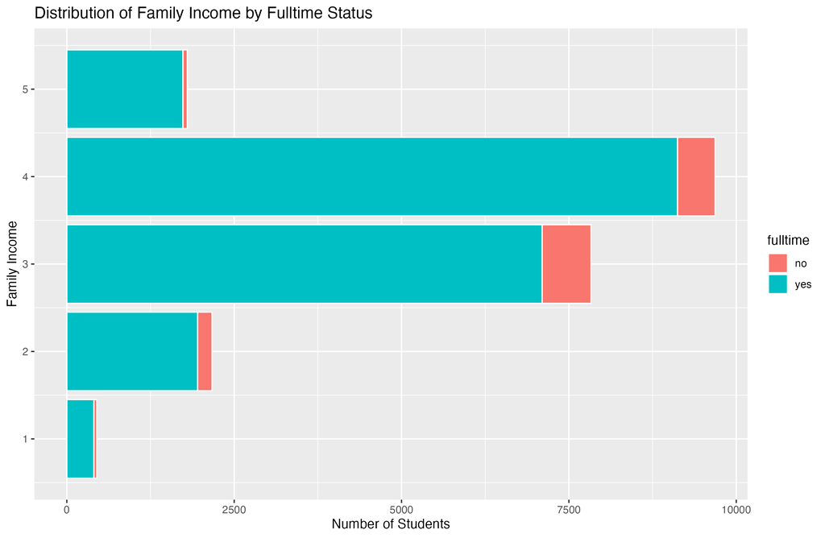

There was no conclusive trend found in the proportion of fulltime and parttime students based on family income ranges. However, this does highlight law school as a large undertaking, one that probably many students intend to give their full focus to. Financial aid opportunities may also influence the decision to be fulltime vs. parttime.

### Law School Tier:

Law school tier ranked from 1-6 (6 being the highest) was established by clusters 1-6 according to undergraduate GPAS and LSAT scores. Below shows the general distribution of applicants and their law school.

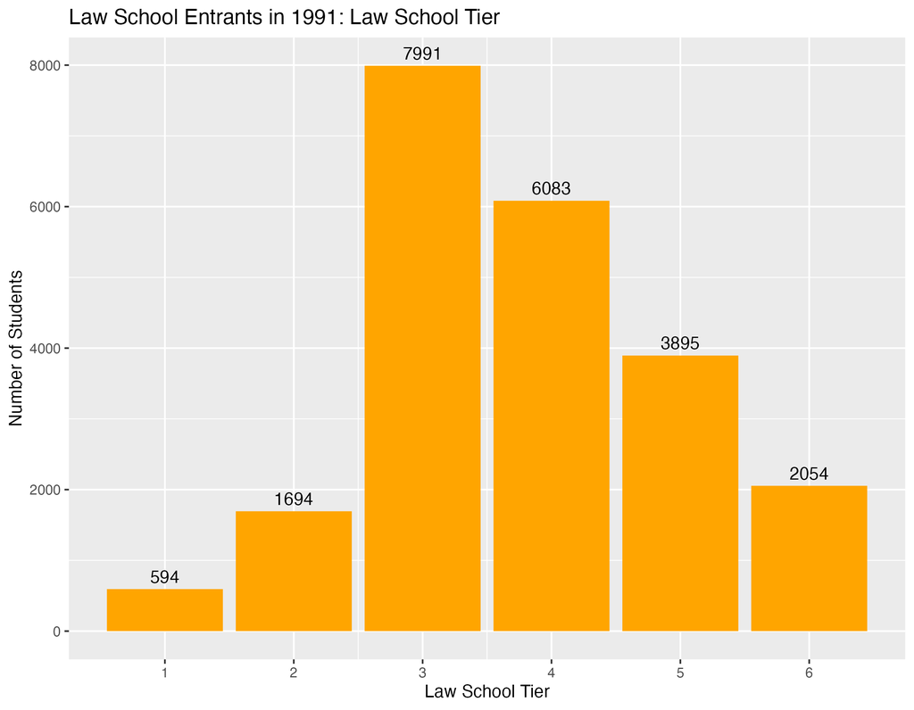

Most students attended schools that were ranked either 3 or 4, with the lowest number of students attending schools ranked 1.

#### *Family Income and Law School Tier:*

Another interesting exploration was to compare family income ranges with the law school tiers that the students attended. (again, the law schools were ranked by and undefined analysis of undergraduate GPA and LSAT scores)

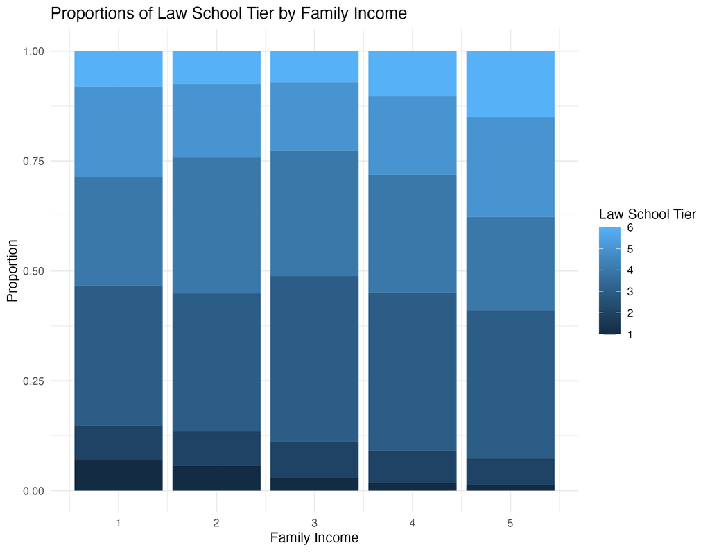

### Law School Graduation Status:

Naturally, not all students who entered law school in 1991 graduated law school. In fact, below shows the total count of students who did and did not graduate.

| grad | count |
| --- | --- |
| no | 89 |
| yes | 22315 |

#### *Graduation Status and Bar Exam Status:*

This dataset shows students who at least attempted law school meaning it shows students who entered law school in fall of 1991. As it is seen earlier, there are students who did not graduate law school. However, below shows a figure that highlights an interesting conclusion about some students who did not graduate law school.

Below shows the distribution:

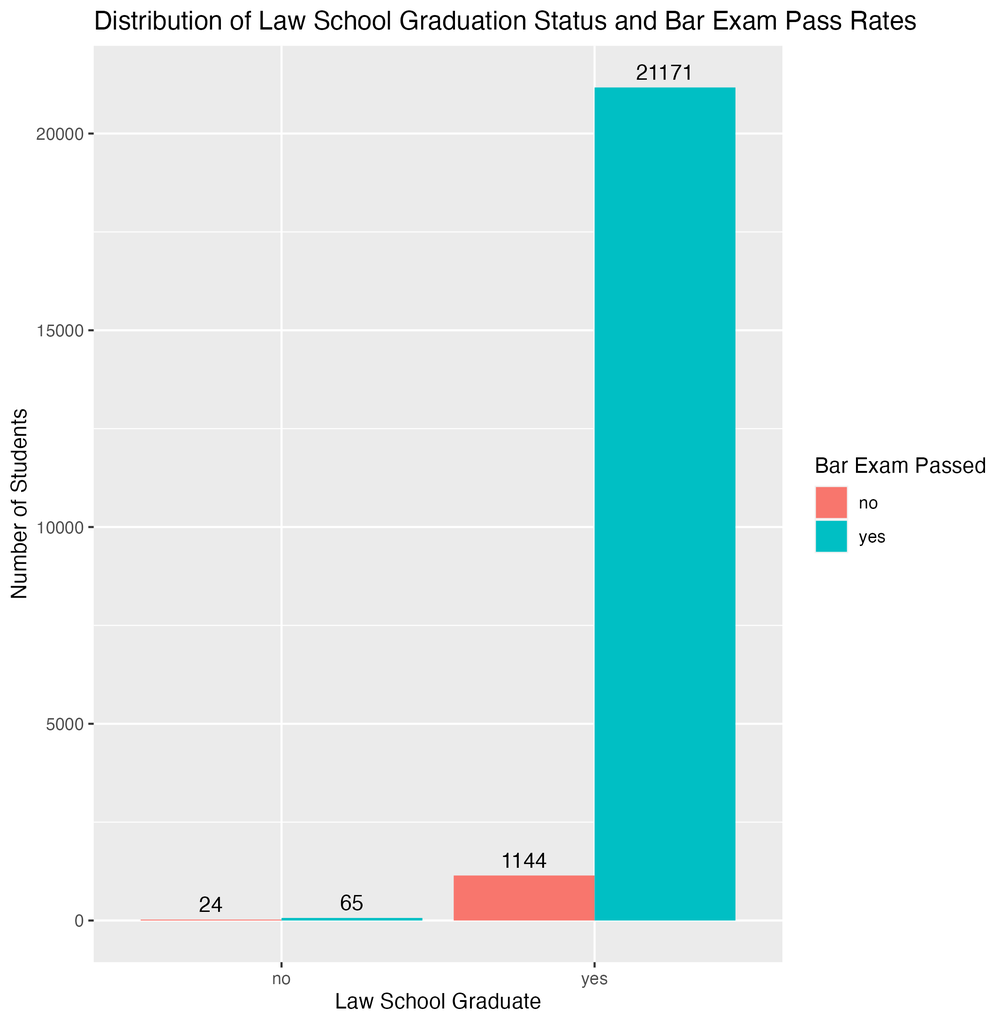

This may be surprising to some, to see a small amount of students who had not graduated and attempted the bar exam, of which 65 passed! This is because there are some states that require some amount of law school (as in, not the full three years). These states are New York, Maine, and West Virginia. The 65 students who passed the bar and the 24 students who didn’t pass the bar (both groups not graduating law school), must have tried for their bar exam in any of these states.

There are also states that do not require ANY law school to attempt the bar exam which are California, Vermont, Virginia, and Washington. However this dataset are all observations of students who entered law school in 1991 so it is not applicable (unless the student immediately dropped out, but that information is not available)

### Bar Exam Attempts:

For those did pass the bar exam, data was collected on when they passed the bar (as in, which attempt did they pass). This data can be seen in the table below:

| bar_passed_attempt | n |
| --- | --- |
| first attempt | 19839 |
| no pass | 1170 |
| second attempt | 1398 |

#### *LSAT Scores and Bar Exam Attempt*

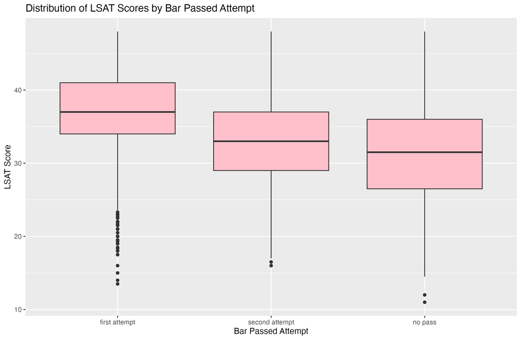

More people with a higher LSAT score passed the bar exam on their first try. And those who did not pass the bar consisted of people with a lower LSAT score.

### Undergraduate GPA:

As always, the GPA scale in 1991 ran on a 4 point scale. It was interesting point of exploration to see how the undergraduate GPAs of 1991 of law school students compared to law school students today.

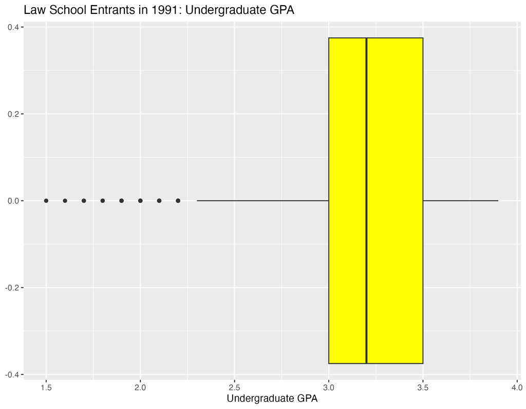

| Median UGPA | Highest UGPA | Lowest UGPA |
| --- | --- | --- |
| 3.2 | 3.9 | 1.5 |

The median undergraduate GPA for students entering law school in 1991 was 3.2. This number, unsurprisingly is less than the median GPAs in recent years. According to U.S. News, the median GPA for law school students entering in 2021 was 3.55.

#### *Undergraduate GPA and Bar Exam Attempt*

Following the distribution of undergraduate GPAs it felt necessary to compare it to bar exam passes, specifically the attempts at passing the bar exam.

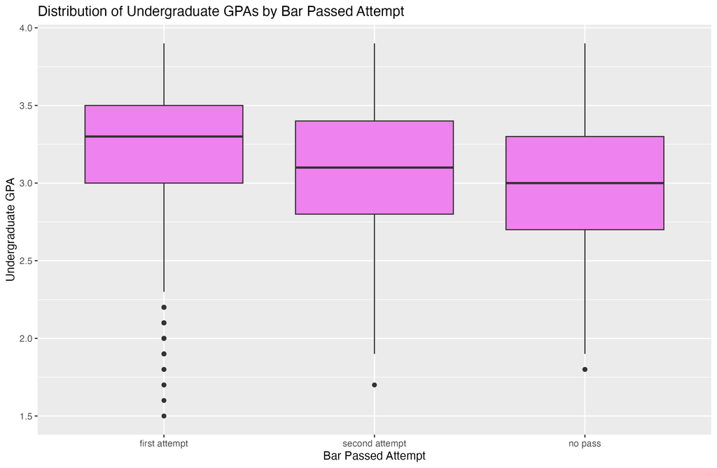

The results are similar to that of the distribution comparing LSAT scores with the bar exam attempts. More people with a higher undergraduate GPA passed the bar exam on their first try. And those who did not pass the bar consisted of people with a lower GPA.

# Conclusion

Overall, this study took a turn in focusing on demographic variables in its EDA. Some conclusions that were drawn from this EDA was the lack of racial diversity in law school students in 1991, with white students being nearly 84% of the population in this study. For black and hispanic law school students in this study, the majority were in the third family income range (and also having the most students in the first family income range).

Unsurprisingly, there were students who did not graduate law school after entering in the fall of 1991. Of those that did not graduate, 89 students still tried for the bar exam (likely in states that allowed for this pursuit) 65 passed the bar exam. LSAT scores and undergraduate GPAs followed a similar trend with students attempting the bar, as those with higher undergraduate GPAs and LSAT scores were the majority of the group of students who passed the bar exam on their first try. As the scores and GPA’s got smaller, the students were more likely to pass on the second attempt or not at all.

For future studies, comparisons between recent studies on law students today and this study would be beneficial to understand the changes. This should also include creating a concrete method of converting the raw LSAT score range used in 1991 to the ranges today, somehow accounting for the changes in test difficulty as well. After some extensive research, many argued there was little worth in trying to convert the values. Another variable to research for might be personal income, as many might not be financially supported by their families and might even be taking out loans for their law school education.

# References

Krinsky, S. L. (2022, December). *Incoming Class of 2022: A Major Advance in Diversity, More Work to Do*. LSAC. https://www.lsac.org/blog/incoming-class-2022-major-advance-diversity-more-work-to-do

Merson, D. (2023, May). *Can You Take the Bar Exam Without Going To Law School?* Juris Education. https://www.juriseducation.com/blog/can-you-take-the-bar-exam-without-going-to-law-school

Wightman, L.F. (1998). *LSAC National Longitudinal Bar Passage Study. LSAC Research Report Series.* Eric. https://eric.ed.gov/?id=ED469370

Wood, S. (2023, January). *What Is a Good College GPA for a Law School Applicant?* U.S. News. https://www.usnews.com/education/best-graduate-schools/top-law-schools/applying/articles/what-is-a-good-college-gpa-for-a-law-school-applicant